# Student Performance Analysis

Miraç Mehmet Yüksel

2023-02-24

Verimiz; cinsiyet, grup, ailenin eğitim düzeyi,kahvaltı durumu,kurs eğitimi, matematik notu, okuma notu ve yazma notu olmak üzere 8 değişkenden oluşmaktadır. Bu projede ilgili veri seti kullanılarak bazı çıkarımlar yapılacaktır.

### Veriyi inceleyelim. [veri](https://www.kaggle.com/datasets/adithyabshetty100/student-performance)

```r
library(readxl)
StudentsPerformance <- read_excel("C:/R/studentdata/StudentsPerformance.xls")
View(StudentsPerformance)
```

### Verideki cinsiyet oranını inceleyelim.

```r
StudentsPerformance
```

| gender | race/ethnicity | parental level of education | lunch | test preparation course | math score | reading score | writing score |
| --- | --- | --- | --- | --- | --- | --- | --- |
| female | group B | bachelor's degree | standard | none | 72 | 72 | 74 |
| female | group C | some college | standard | completed | 69 | 90 | 88 |
| female | group B | master's degree | standard | none | 90 | 95 | 93 |
| male | group A | associate's degree | free/reduced | none | 47 | 57 | 44 |
| male | group C | some college | standard | none | 76 | 78 | 75 |
| female | group B | associate's degree | standard | none | 71 | 83 | 78 |
| female | group B | some college | standard | completed | 88 | 95 | 92 |
| male | group B | some college | free/reduced | none | 40 | 43 | 39 |
| male | group D | high school | free/reduced | completed | 64 | 64 | 67 |
| female | group B | high school | free/reduced | none | 38 | 60 | 50 |

[output cut: 990 more lines]

```r
gender_freq <- table(StudentsPerformance$gender)
gender_ratio <- gender_freq / sum(gender_freq)
gender_ratio
```

```
##
## female   male
##  0.518  0.482
```

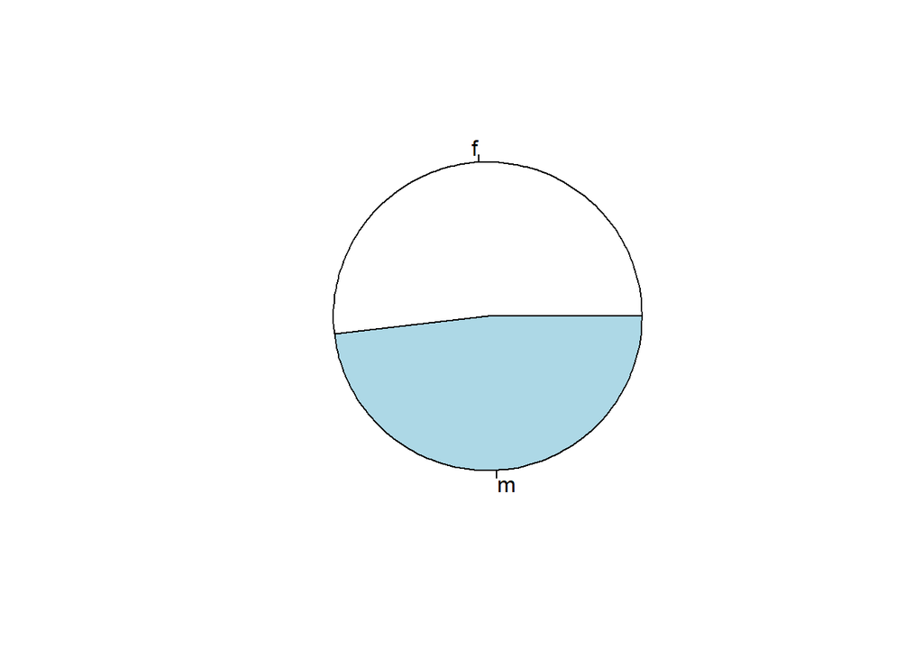

```r
gender_ratio_pie<- c(0.518,0.482)
pie(gender_ratio_pie, label=c( "f", "m"))
```

### Cinsiyete göre matematik notu dağılımını görelim.

```r
library(ggplot2)
StudentsPerformance
```

| gender | race/ethnicity | parental level of education | lunch | test preparation course | math score | reading score | writing score |
| --- | --- | --- | --- | --- | --- | --- | --- |
| female | group B | bachelor's degree | standard | none | 72 | 72 | 74 |
| female | group C | some college | standard | completed | 69 | 90 | 88 |
| female | group B | master's degree | standard | none | 90 | 95 | 93 |
| male | group A | associate's degree | free/reduced | none | 47 | 57 | 44 |
| male | group C | some college | standard | none | 76 | 78 | 75 |
| female | group B | associate's degree | standard | none | 71 | 83 | 78 |
| female | group B | some college | standard | completed | 88 | 95 | 92 |
| male | group B | some college | free/reduced | none | 40 | 43 | 39 |
| male | group D | high school | free/reduced | completed | 64 | 64 | 67 |
| female | group B | high school | free/reduced | none | 38 | 60 | 50 |

[output cut: 990 more lines]

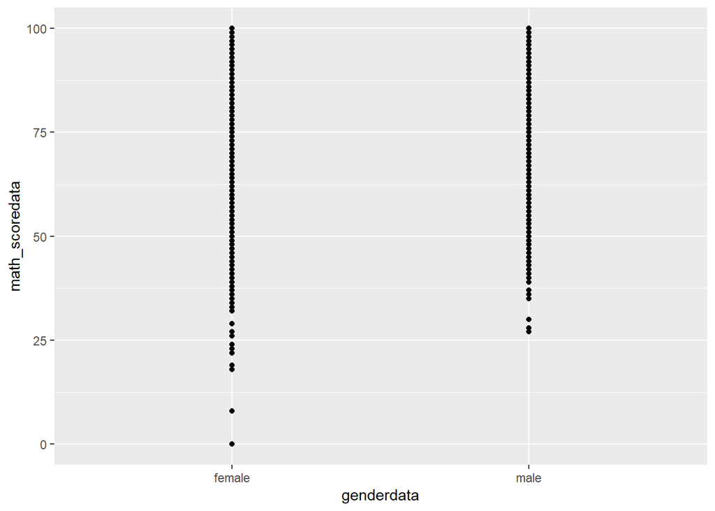

```r
genderdata<- StudentsPerformance$gender
math_scoredata<- StudentsPerformance$'math score'
ggplot(StudentsPerformance, aes(x =genderdata , y =math_scoredata )) +
  geom_point()
```

#### Öğrencilerin cinsiyet bazında matematik notları incelendiğinde en düşük notun bir kız öğrenciye ait olduğu; erkek öğrencilerin en düşük notunun ise 25’ten büyük olduğu görülmektedir.

### Yazma notları ile okuma notları arasındaki ilişkiyi yorumlayalım.

```r
cor.test(StudentsPerformance$`writing score`, StudentsPerformance$`reading score`)
```

```
##
##  Pearson's product-moment correlation
##
## data:  StudentsPerformance$`writing score` and StudentsPerformance$`reading score`
## t = 101.23, df = 998, p-value < 2.2e-16
## alternative hypothesis: true correlation is not equal to 0
## 95 percent confidence interval:
##  0.9487506 0.9597921
## sample estimates:
##       cor
## 0.9545981
```

#### Okuma ve yazma notları arasındaki korelasyon katsayısının 0.95 olduğu bulunmuştur. Bu değer bize ilgili sınavların notları arasındaki ilişkinin güçlü ve pozitif yönlü olduğunu göstermektedir. Yani bu verilere göre yazma notu yükseldikçe okuma notu da yükselir diyebiliriz.

### Verideki okuma, yazma ve matematik notlarının ortalamalarına bakalım.

```r
names(StudentsPerformance) <- c( "gender", "group", "parental_loe", "lunch", "course", "mathscore", "readingscore", "writingscore")
names(StudentsPerformance)
```

```
## [1] "gender"       "group"        "parental_loe" "lunch"        "course"
## [6] "mathscore"    "readingscore" "writingscore"
```

```r
StudentsPerformance
```

| gender | group | parental_loe | lunch | course | mathscore | readingscore | writingscore |
| --- | --- | --- | --- | --- | --- | --- | --- |
| female | group B | bachelor's degree | standard | none | 72 | 72 | 74 |
| female | group C | some college | standard | completed | 69 | 90 | 88 |
| female | group B | master's degree | standard | none | 90 | 95 | 93 |
| male | group A | associate's degree | free/reduced | none | 47 | 57 | 44 |
| male | group C | some college | standard | none | 76 | 78 | 75 |
| female | group B | associate's degree | standard | none | 71 | 83 | 78 |
| female | group B | some college | standard | completed | 88 | 95 | 92 |
| male | group B | some college | free/reduced | none | 40 | 43 | 39 |
| male | group D | high school | free/reduced | completed | 64 | 64 | 67 |
| female | group B | high school | free/reduced | none | 38 | 60 | 50 |

[output cut: 990 more lines]

```r
scores <- c("mathscore", "readingscore", "writingscore")
colMeans(StudentsPerformance[, scores])
```

```
##    mathscore readingscore writingscore
##       66.089       69.169       68.054
```

#### Not ortalamalarına bakıldığında bu öğrencilerin okuma sınavında yazma ve matematik sınavına göre daha başarılı olduğunu görülmektedir.

### Öğrencilerin grup bazında sınav not ortalamalarını bulalım.

```r
groupA_data <- StudentsPerformance[StudentsPerformance$group == "group A", ]
groupA_data
```

| gender | group | parental_loe | lunch | course | mathscore | readingscore | writingscore |
| --- | --- | --- | --- | --- | --- | --- | --- |
| male | group A | associate's degree | free/reduced | none | 47 | 57 | 44 |
| male | group A | some college | standard | completed | 78 | 72 | 70 |
| female | group A | master's degree | standard | none | 50 | 53 | 58 |
| male | group A | master's degree | free/reduced | none | 73 | 74 | 72 |
| female | group A | associate's degree | standard | completed | 55 | 65 | 62 |
| male | group A | some high school | free/reduced | none | 39 | 39 | 34 |
| male | group A | associate's degree | free/reduced | none | 62 | 61 | 55 |
| female | group A | associate's degree | free/reduced | none | 41 | 51 | 48 |
| male | group A | bachelor's degree | standard | completed | 80 | 78 | 81 |
| male | group A | some college | free/reduced | completed | 50 | 47 | 54 |

[output cut: 79 more lines]

```r
scoresA <- c("mathscore", "readingscore", "writingscore")
colMeans(groupA_data[, scoresA])
```

```
##    mathscore readingscore writingscore
##     61.62921     64.67416     62.67416
```

```r
groupB_data <- StudentsPerformance[StudentsPerformance$group == "group B", ]
groupB_data
```

| gender | group | parental_loe | lunch | course | mathscore | readingscore | writingscore |
| --- | --- | --- | --- | --- | --- | --- | --- |
| female | group B | bachelor's degree | standard | none | 72 | 72 | 74 |
| female | group B | master's degree | standard | none | 90 | 95 | 93 |
| female | group B | associate's degree | standard | none | 71 | 83 | 78 |
| female | group B | some college | standard | completed | 88 | 95 | 92 |
| male | group B | some college | free/reduced | none | 40 | 43 | 39 |
| female | group B | high school | free/reduced | none | 38 | 60 | 50 |
| female | group B | high school | standard | none | 65 | 81 | 73 |
| female | group B | some high school | free/reduced | none | 18 | 32 | 28 |
| female | group B | some college | free/reduced | completed | 65 | 75 | 70 |
| male | group B | some college | standard | none | 69 | 54 | 55 |

[output cut: 180 more lines]

```r
scoresB <- c("mathscore", "readingscore", "writingscore")
colMeans(groupB_data[, scoresB])
```

```
##    mathscore readingscore writingscore
##     63.45263     67.35263     65.60000
```

```r
groupC_data <- StudentsPerformance[StudentsPerformance$group == "group C", ]
groupC_data
```

| gender | group | parental_loe | lunch | course | mathscore | readingscore | writingscore |
| --- | --- | --- | --- | --- | --- | --- | --- |
| female | group C | some college | standard | completed | 69 | 90 | 88 |
| male | group C | some college | standard | none | 76 | 78 | 75 |
| male | group C | associate's degree | standard | none | 58 | 54 | 52 |
| female | group C | some high school | standard | none | 69 | 75 | 78 |
| male | group C | high school | standard | none | 88 | 89 | 86 |
| male | group C | master's degree | free/reduced | completed | 46 | 42 | 46 |
| female | group C | associate's degree | free/reduced | none | 54 | 58 | 61 |
| female | group C | some high school | standard | none | 69 | 73 | 73 |
| female | group C | bachelor's degree | standard | none | 67 | 69 | 75 |
| male | group C | high school | standard | none | 70 | 70 | 65 |

[output cut: 309 more lines]

```r
scoresC <- c("mathscore", "readingscore", "writingscore")
colMeans(groupC_data[, scoresC])
```

```
##    mathscore readingscore writingscore
##     64.46395     69.10345     67.82759
```

```r
groupD_data <- StudentsPerformance[StudentsPerformance$group == "group D", ]
groupD_data
```

| gender | group | parental_loe | lunch | course | mathscore | readingscore | writingscore |
| --- | --- | --- | --- | --- | --- | --- | --- |
| male | group D | high school | free/reduced | completed | 64 | 64 | 67 |
| male | group D | associate's degree | standard | none | 40 | 52 | 43 |
| male | group D | high school | standard | none | 66 | 69 | 63 |
| male | group D | some college | standard | none | 44 | 54 | 53 |
| male | group D | bachelor's degree | free/reduced | completed | 74 | 71 | 80 |
| female | group D | master's degree | standard | none | 62 | 70 | 75 |
| female | group D | some college | standard | none | 69 | 74 | 74 |
| male | group D | some college | standard | none | 40 | 42 | 38 |
| female | group D | associate's degree | standard | none | 74 | 81 | 83 |
| female | group D | some high school | free/reduced | none | 50 | 64 | 59 |

[output cut: 252 more lines]

```r
scoresD <- c("mathscore", "readingscore", "writingscore")
colMeans(groupD_data[, scoresD])
```

```
##    mathscore readingscore writingscore
##     67.36260     70.03053     70.14504
```

### Öğrencilerin gruplarına göre sınav ortalamalarını görelim.

```r
scoremeansA<-colMeans(groupA_data[, scoresA])
scoremeansB<-colMeans(groupB_data[, scoresB])
scoremeansC<-colMeans(groupC_data[, scoresC])
scoremeansD<-colMeans(groupD_data[, scoresD])
scoremeansA
```

```
##    mathscore readingscore writingscore
##     61.62921     64.67416     62.67416
```

```r
scoremeansB
```

```
##    mathscore readingscore writingscore
##     63.45263     67.35263     65.60000
```

```r
scoremeansC
```

```
##    mathscore readingscore writingscore
##     64.46395     69.10345     67.82759
```

```r
scoremeansD
```

```
##    mathscore readingscore writingscore
##     67.36260     70.03053     70.14504
```

### Öğrencilerin kahvaltı durumuna göre okuma sınavı ortalamalarını bulalım.

```r
lunch_std <- StudentsPerformance[StudentsPerformance$lunch == "standard", ]
lunch_std
```

| gender | group | parental_loe | lunch | course | mathscore | readingscore | writingscore |
| --- | --- | --- | --- | --- | --- | --- | --- |
| female | group B | bachelor's degree | standard | none | 72 | 72 | 74 |
| female | group C | some college | standard | completed | 69 | 90 | 88 |
| female | group B | master's degree | standard | none | 90 | 95 | 93 |
| male | group C | some college | standard | none | 76 | 78 | 75 |
| female | group B | associate's degree | standard | none | 71 | 83 | 78 |
| female | group B | some college | standard | completed | 88 | 95 | 92 |
| male | group C | associate's degree | standard | none | 58 | 54 | 52 |
| male | group D | associate's degree | standard | none | 40 | 52 | 43 |
| female | group B | high school | standard | none | 65 | 81 | 73 |
| male | group A | some college | standard | completed | 78 | 72 | 70 |

[output cut: 635 more lines]

```r
lunch_std_data <- c("readingscore")
colMeans(lunch_std[, lunch_std_data])
```

```
## readingscore
##     71.65426
```

```r
lunch_free <- StudentsPerformance[StudentsPerformance$lunch == "free/reduced", ]
lunch_free
```

| gender | group | parental_loe | lunch | course | mathscore | readingscore | writingscore |
| --- | --- | --- | --- | --- | --- | --- | --- |
| male | group A | associate's degree | free/reduced | none | 47 | 57 | 44 |
| male | group B | some college | free/reduced | none | 40 | 43 | 39 |
| male | group D | high school | free/reduced | completed | 64 | 64 | 67 |
| female | group B | high school | free/reduced | none | 38 | 60 | 50 |
| female | group B | some high school | free/reduced | none | 18 | 32 | 28 |
| male | group C | master's degree | free/reduced | completed | 46 | 42 | 46 |
| female | group C | associate's degree | free/reduced | none | 54 | 58 | 61 |
| female | group B | some college | free/reduced | completed | 65 | 75 | 70 |
| male | group D | bachelor's degree | free/reduced | completed | 74 | 71 | 80 |
| male | group A | master's degree | free/reduced | none | 73 | 74 | 72 |

[output cut: 345 more lines]

```r
lunch_free_data <- c("readingscore")
colMeans(lunch_free[, lunch_free_data])
```

```
## readingscore
##     64.65352
```

### Öğrencilerin kahvaltı durumlarına göre okuma sınavı ortalamalarını görelim.

```r
lunch_std_mean<-colMeans(lunch_std[, lunch_std_data])
lunch_free_mean<-colMeans(lunch_free[, lunch_free_data])
lunch_std_mean
```

```
## readingscore
##     71.65426
```

```r
lunch_free_mean
```

```
## readingscore
##     64.65352
```

#### Bulduğumuz sonuçlara göre standart kahvaltı ile beslenen öğrencilerin not ortalaması 71.65 iken azaltılmış kahvaltı ile beslenen öğrencilerin not ortalaması 64.65’tür. Bu durumda da standart kahvaltı ile beslenen öğrencilerin okuma sınavı notlarının, azaltılmış kahvaltı ile beslenen öğrencilerin okuma sınavı notlarından daha yüksek olduğu söylenebilir.

### Öğrencilerin cinsiyet bazında matematik not ortalamalarını bulalım.

```r
gender_female <- StudentsPerformance[StudentsPerformance$gender == "female", ]
gender_female
```

| gender | group | parental_loe | lunch | course | mathscore | readingscore | writingscore |
| --- | --- | --- | --- | --- | --- | --- | --- |
| female | group B | bachelor's degree | standard | none | 72 | 72 | 74 |
| female | group C | some college | standard | completed | 69 | 90 | 88 |
| female | group B | master's degree | standard | none | 90 | 95 | 93 |
| female | group B | associate's degree | standard | none | 71 | 83 | 78 |
| female | group B | some college | standard | completed | 88 | 95 | 92 |
| female | group B | high school | free/reduced | none | 38 | 60 | 50 |
| female | group B | high school | standard | none | 65 | 81 | 73 |
| female | group A | master's degree | standard | none | 50 | 53 | 58 |
| female | group C | some high school | standard | none | 69 | 75 | 78 |
| female | group B | some high school | free/reduced | none | 18 | 32 | 28 |

[output cut: 508 more lines]

```r
gender_female_ms <- c("mathscore")
colMeans(gender_female[, gender_female_ms])
```

```
## mathscore
##   63.6332
```

```r
gender_male <- StudentsPerformance[StudentsPerformance$gender == "male", ]
gender_male
```

| gender | group | parental_loe | lunch | course | mathscore | readingscore | writingscore |
| --- | --- | --- | --- | --- | --- | --- | --- |
| male | group A | associate's degree | free/reduced | none | 47 | 57 | 44 |
| male | group C | some college | standard | none | 76 | 78 | 75 |
| male | group B | some college | free/reduced | none | 40 | 43 | 39 |
| male | group D | high school | free/reduced | completed | 64 | 64 | 67 |
| male | group C | associate's degree | standard | none | 58 | 54 | 52 |
| male | group D | associate's degree | standard | none | 40 | 52 | 43 |
| male | group A | some college | standard | completed | 78 | 72 | 70 |
| male | group C | high school | standard | none | 88 | 89 | 86 |
| male | group C | master's degree | free/reduced | completed | 46 | 42 | 46 |
| male | group D | high school | standard | none | 66 | 69 | 63 |

[output cut: 472 more lines]

```r
gender_male_ms <- c("mathscore")
colMeans(gender_male[, gender_male_ms])
```

```
## mathscore
##  68.72822
```

### Öğrencilerin cinsiyet bazında matematik not ortalamalarını inceleyelim.

```r
gender_female_mean<-colMeans(gender_female[, gender_female_ms])
gender_male_mean<-colMeans(gender_male[, gender_male_ms])
gender_female_mean
```

```
## mathscore
##   63.6332
```

```r
gender_male_mean
```

```
## mathscore
##  68.72822
```

#### Bulduğumuz sonuca göre matematik sınavı için erkek öğrencilerin kız öğrencilerden daha başarılı olduğunu söyleyebiliriz.

### Öğrencilerin 3 ders için aldıkları notların ortalamasını yeni bir değişken sütunu olarak ekleyelim.

```r
StudentsPerformance$mean <- rowMeans(StudentsPerformance[, c("mathscore", "readingscore", "writingscore")])
StudentsPerformance
```

| gender | group | parental_loe | lunch | course | mathscore | readingscore | writingscore | mean |
| --- | --- | --- | --- | --- | --- | --- | --- | --- |
| female | group B | bachelor's degree | standard | none | 72 | 72 | 74 | 72.66667 |
| female | group C | some college | standard | completed | 69 | 90 | 88 | 82.33333 |
| female | group B | master's degree | standard | none | 90 | 95 | 93 | 92.66667 |
| male | group A | associate's degree | free/reduced | none | 47 | 57 | 44 | 49.33333 |
| male | group C | some college | standard | none | 76 | 78 | 75 | 76.33333 |
| female | group B | associate's degree | standard | none | 71 | 83 | 78 | 77.33333 |
| female | group B | some college | standard | completed | 88 | 95 | 92 | 91.66667 |
| male | group B | some college | free/reduced | none | 40 | 43 | 39 | 40.66667 |
| male | group D | high school | free/reduced | completed | 64 | 64 | 67 | 65.00000 |
| female | group B | high school | free/reduced | none | 38 | 60 | 50 | 49.33333 |

[output cut: 990 more lines]

### Öğrencilerin sınava hazırlık kursunu tamamlama durumlarına göre sınav notları ortalamalarını inceleyelim.

```r
course_none_data <- StudentsPerformance[StudentsPerformance$course == "none", ]
course_none_data
```

| gender | group | parental_loe | lunch | course | mathscore | readingscore | writingscore | mean |
| --- | --- | --- | --- | --- | --- | --- | --- | --- |
| female | group B | bachelor's degree | standard | none | 72 | 72 | 74 | 72.66667 |
| female | group B | master's degree | standard | none | 90 | 95 | 93 | 92.66667 |
| male | group A | associate's degree | free/reduced | none | 47 | 57 | 44 | 49.33333 |
| male | group C | some college | standard | none | 76 | 78 | 75 | 76.33333 |
| female | group B | associate's degree | standard | none | 71 | 83 | 78 | 77.33333 |
| male | group B | some college | free/reduced | none | 40 | 43 | 39 | 40.66667 |
| female | group B | high school | free/reduced | none | 38 | 60 | 50 | 49.33333 |
| male | group C | associate's degree | standard | none | 58 | 54 | 52 | 54.66667 |
| male | group D | associate's degree | standard | none | 40 | 52 | 43 | 45.00000 |
| female | group B | high school | standard | none | 65 | 81 | 73 | 73.00000 |

[output cut: 632 more lines]

```r
score_mean_none <- c("mean")
colMeans(course_none_data[, score_mean_none])
```

```
##     mean
## 65.03894
```

```r
course_completed_data <- StudentsPerformance[StudentsPerformance$course == "completed", ]
course_completed_data
```

| gender | group | parental_loe | lunch | course | mathscore | readingscore | writingscore | mean |
| --- | --- | --- | --- | --- | --- | --- | --- | --- |
| female | group C | some college | standard | completed | 69 | 90 | 88 | 82.33333 |
| female | group B | some college | standard | completed | 88 | 95 | 92 | 91.66667 |
| male | group D | high school | free/reduced | completed | 64 | 64 | 67 | 65.00000 |
| male | group A | some college | standard | completed | 78 | 72 | 70 | 73.33333 |
| male | group C | master's degree | free/reduced | completed | 46 | 42 | 46 | 44.66667 |
| female | group B | some college | free/reduced | completed | 65 | 75 | 70 | 70.00000 |
| male | group D | bachelor's degree | free/reduced | completed | 74 | 71 | 80 | 75.00000 |
| male | group E | associate's degree | standard | completed | 81 | 81 | 79 | 80.33333 |
| female | group D | associate's degree | free/reduced | completed | 75 | 90 | 88 | 84.33333 |
| male | group B | some college | free/reduced | completed | 59 | 65 | 66 | 63.33333 |

[output cut: 348 more lines]

```r
score_mean_comp <- c("mean")
colMeans(course_completed_data[, score_mean_comp])
```

```
##     mean
## 72.66946
```

#### Sonuca bakıldığında kursa katılmayan öğrencilerin 3 sınavda aldıkları notların ortalaması ortalama 65.03 iken sınava hazırlık kursuna katılan öğrencilerin 3 sınavda aldıkları notların ortalaması ortalama 72.66’dır. Buna göre sınava hazırlık kursunun, öğrencileri ilgili sınavlara hazırlamada pozitif etkisi olduğu çıkarımı yapılabilir.

### Öğrencilerin cinsiyetine göre sınav notu ortalamalarının dağılımı şu şekildedir;

```r
library(ggplot2)
StudentsPerformance
```

| gender | group | parental_loe | lunch | course | mathscore | readingscore | writingscore | mean |
| --- | --- | --- | --- | --- | --- | --- | --- | --- |
| female | group B | bachelor's degree | standard | none | 72 | 72 | 74 | 72.66667 |
| female | group C | some college | standard | completed | 69 | 90 | 88 | 82.33333 |
| female | group B | master's degree | standard | none | 90 | 95 | 93 | 92.66667 |
| male | group A | associate's degree | free/reduced | none | 47 | 57 | 44 | 49.33333 |
| male | group C | some college | standard | none | 76 | 78 | 75 | 76.33333 |
| female | group B | associate's degree | standard | none | 71 | 83 | 78 | 77.33333 |
| female | group B | some college | standard | completed | 88 | 95 | 92 | 91.66667 |
| male | group B | some college | free/reduced | none | 40 | 43 | 39 | 40.66667 |
| male | group D | high school | free/reduced | completed | 64 | 64 | 67 | 65.00000 |
| female | group B | high school | free/reduced | none | 38 | 60 | 50 | 49.33333 |

[output cut: 990 more lines]

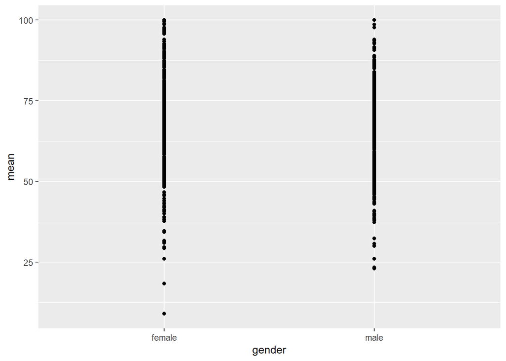

```r
ggplot(StudentsPerformance, aes(x = gender, y = mean)) +
  geom_point()
```

#### Yukarıdaki grafik, öğrencilerin cinsiyet bazında 3 sınavdan aldığı notların ortalamasının dağılımını göstermektedir. Grafikte görüldüğü üzere erkeklerin en düşük ortalamasından da düşük not ortalamasına sahip 2 kız öğrenci vardır.

#### Not ortalaması 75 ile 100 arasında olan öğrencilere bakıldığında bu aralıkta kız öğrencilerin erkek öğrencilerden daha yoğun olduğunu görüyoruz.

### Öğrencilerin gruplara göre sınav notu ortalamalarının dağılımı şu şekildedir;

```r
library(ggplot2)
StudentsPerformance
```

| gender | group | parental_loe | lunch | course | mathscore | readingscore | writingscore | mean |
| --- | --- | --- | --- | --- | --- | --- | --- | --- |
| female | group B | bachelor's degree | standard | none | 72 | 72 | 74 | 72.66667 |
| female | group C | some college | standard | completed | 69 | 90 | 88 | 82.33333 |
| female | group B | master's degree | standard | none | 90 | 95 | 93 | 92.66667 |
| male | group A | associate's degree | free/reduced | none | 47 | 57 | 44 | 49.33333 |
| male | group C | some college | standard | none | 76 | 78 | 75 | 76.33333 |
| female | group B | associate's degree | standard | none | 71 | 83 | 78 | 77.33333 |
| female | group B | some college | standard | completed | 88 | 95 | 92 | 91.66667 |
| male | group B | some college | free/reduced | none | 40 | 43 | 39 | 40.66667 |
| male | group D | high school | free/reduced | completed | 64 | 64 | 67 | 65.00000 |
| female | group B | high school | free/reduced | none | 38 | 60 | 50 | 49.33333 |

[output cut: 990 more lines]

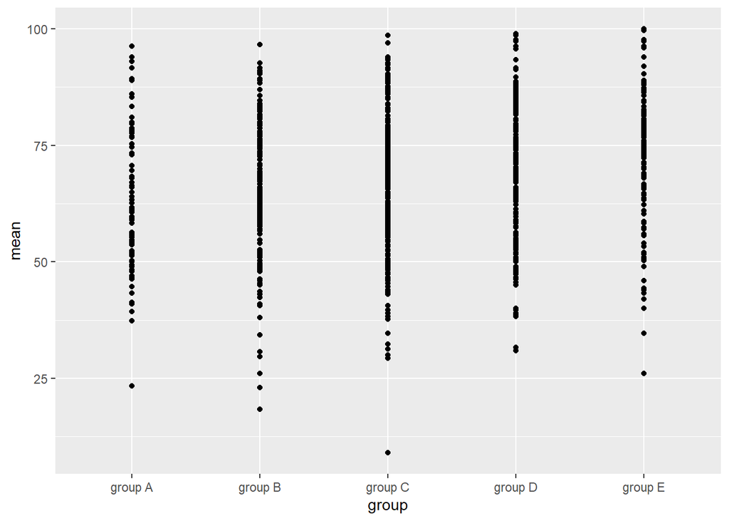

```r
ggplot(StudentsPerformance, aes(x = group, y = mean)) +
   geom_point()
```

#### Yukarıdaki grafikte grup bazında öğrencilerin not ortalamalarına ilişkin dağılım görülmektedir. Grafikten görüldüğü üzere en düşük not ortalamasına sahip öğrenci C grubunda bulunmaktadır. En yüksek not ortalamasına sahip öğrenci ise E grubundadır.